# Final Project, STAT 6210

Akeem Ajede, Cary Burdick, Kaelyn Fogelman, Maria Terra

12/04/2020

GitHub Repo: Final_Project_Group_5

# macklinear

The goal of this project is to develop an R package that implements a foundational machine learning algorithm - linear regression. The scope of the package includes producing outputs such as statistical confidence intervals (C.I.) at the user selected significance level and method of solution. The two methods of solution available in the developed package are the asymptotic and the bootstrap methods.

You can also check our Shiny app using this link: [Shiny App](https://finalprojectgroup5.shinyapps.io/shinymacklinear/)

## Installation

1. Download and install/update R.
2. Open R and install the development version of the package from [GitHub](https://github.com/AU-R-Programming/Final_Project_Group_5) with:

```
# install.packages("devtools")
devtools::install_github("AU-R-Programming/Final_Project_Group_5")
library(macklinear)
```

The following vignette will walk you through some examples of how to use the functions and obtain their output. To get even more information about the two functions and the package itself while using them yourself in R, run these to see their help pages after installation:

```
?my_lm
?plot_func
help(package = macklinear)
```

## Usage

There are two functions contained in the package: `my_lm()` for building a linear regression model and outputting related statistics, and `plot_func()` for creating plots of some of these statistics from linear regression. The full form of each function with each argument and default value, if any, is listed below:

```r
my_lm(response, covariates, alpha = 0.05, method = "asymptotic", intercept = 1)

plot_func(lm)
```

The function `my_lm()` needs five parameters: `response`, `covariates`, `alpha`, `method`, & `intercept`.

- `response` - a one-dimensional vector of numerical y values used as the response variable in the regression equation.
- `covariates` - a matrix of numerical x values used as the explanatory variable(s) in the regression equation. Can be one-dimensional if running simple linear regression or two-dimensional if running multiple linear regression.
- `alpha` - a value between 0 and 1 that specifies the alpha level with which to form the two-tailed confidence interval for beta.hat. The default value is 0.05.
- `method` - a string value indicating the method used for generating the confidence intervals for beta.hat. The asymptotic method will be performed if “asymptotic” or “a” are specified. The bootstrap method will be performed if “bootstrap” or “b” are specified. The default value is “asymptotic”.
- `intercept` - a binary value of either 1 or -1 specifying if the model should estimate the intercept. A value of 1 will include the intercept while -1 will exclude the intercept. The default value is 1.

## Tutorial - Simple Linear Regression

### Cars Dataset

This is a basic example using the base R data set, cars, which shows you how to solve a common problem.  
The cars data set has two variables, **speed** and **distance**. We will use the `my_lm` function of the `macklinear` package to fit a regression and estimate the fit of our explanatory variable to our response variable.

```r
library(macklinear)

head(cars)
```

```
#>   speed dist
#> 1     4    2
#> 2     4   10
#> 3     7    4
#> 4     7   22
#> 5     8   16
#> 6     9   10
```

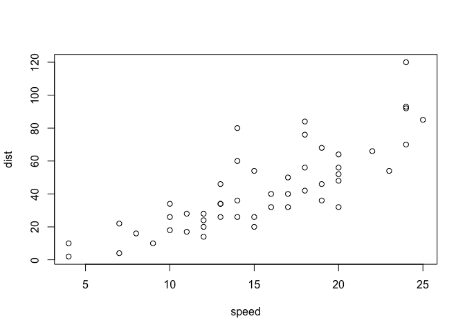

```r
plot(cars)
```

We can see that the y variable, or the response variable, is distance. The variable **“dist”** is our `response` parameter in our function.  
The x variable, or the explanatory variable, is speed. The variable **“speed”** is our `covariate` parameter in our function.  
`Alpha` is our level of significance set for our function. Alpha is generally set at 0.05, indicating a 95% confidence interval. If you do not set 0 < alpha < 1, you will have a warning generated as the true value of alpha must be between 0 and 1 and the function will not complete. Additionally, if you do not set 0.01 < alpha < 0.1, you will have a warning generated, but the function will still run as intended. Alpha is typically between 0.01 and 0.1, therefore you should consider using a different alpha value.  
The parameter `method` is used to determine the method with which confidence intervals for β will be generated. You can choose to use a “bootstrap” or “asymptotic” method for generating confidence intervals. The “asymptotic” method is a more mathematical approach using the square root of the variance of each β to construct a confidence interval. The “bootstrap” method simply generates a new matrix of x and y values with the same length of the original data by sampling with replacement from the original data. This is repeated 1000 times. The βs are estimated for each of the 1000 new datasets, and the confidence intervals are constructed by taking the upper and lower quantiles of the distribution of these βs. The quantiles are specified by `alpha`.  
The final parameter of the function is `intercept`. As stated before, this determines whether to include an intercept in the model or not.  
We will now use the `my_lm()` function to analyze the relationship between **speed and distance**, with a **95%** confidence interval and a **bootstrap** approach for generating confidence interval, and including the intercept.

```r
fit_my_lm <- my_lm(cars$dist, cars$speed, alpha = 0.05, method = "bootstrap", intercept = 1)
fit_my_lm
```

```
#> $y.avg
#>       [,1]
#> [1,] 42.98
#>
#> $sigma2
#>          [,1]
#> [1,] 236.5317
#>
#> $mspe
#>          [,1]
#> [1,] 227.0704
#>
#> $ssm
#>          [,1]
#> [1,] 21185.46
#>
#> $sse
#>          [,1]
#> [1,] 11353.52
#>
#> $f.stat
#>          [,1]
#> [1,] 89.56711
#>
#> $p.value
#>              [,1]
#> [1,] 1.489836e-12
#>
#> $y.table
#>       actual.y.values     y.hat   residual
#>  [1,]               2 -1.849460   3.849460
#>  [2,]              10 -1.849460  11.849460
#>  [3,]               4  9.947766  -5.947766
#>  [4,]              22  9.947766  12.052234
#>  [5,]              16 13.880175   2.119825
#>  [6,]              10 17.812584  -7.812584
#>  [7,]              18 21.744993  -3.744993
#>  [8,]              26 21.744993   4.255007
#>  [9,]              34 21.744993  12.255007
#> [10,]              17 25.677401  -8.677401
```

[output cut: 30 more lines]

```
#> [41,]              52 61.069080  -9.069080
#> [42,]              56 61.069080  -5.069080
#> [43,]              64 61.069080   2.930920
#> [44,]              66 68.933898  -2.933898
#> [45,]              54 72.866307 -18.866307
#> [46,]              70 76.798715  -6.798715
#> [47,]              92 76.798715  15.201285
#> [48,]              93 76.798715  16.201285
#> [49,]             120 76.798715  43.201285
#> [50,]              85 80.731124   4.268876
#>
#> $beta.table
#>          beta variance.beta CI.lower.bound CI.upper.bound
#> b0 -17.579095    45.6765135     -28.921314      -6.798130
#> b1   3.932409     0.1726509       3.122158       4.707382
```

Our function returns multiple statistical outputs regarding the relationship between our x and y variables, **speed** and **distance**.

- `y.avg` is the mean of all y-values in the data set
- `sigma2` is an estimate of the residual variance
- `mspe` is an estimate of how well the model predicts the response variable
- `ssm` is the model sum of squares
- `sse` is the error sum of squares, which quantifies how much the residual data points vary around the estimated regression line points, y-hat
- `f.stat` is the f statistic for use in f test and model fitting
- `p.value` is the probability of the observed data, or data more extreme, given the null hypothesis is true

There are two tables that are also output with additional information. From the output `y.table`:

- `actual.y.values` are the response variable values taken from the input data
- `y.hat` is the predicted y-value
- `residual` is the difference between the observed y-value and the predicted y-value, or y.hat

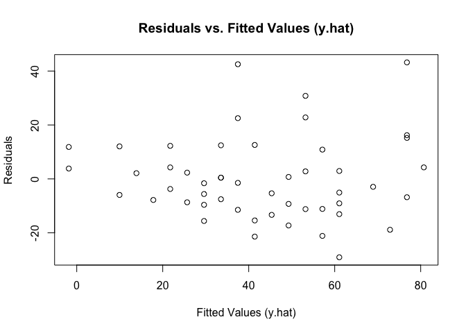

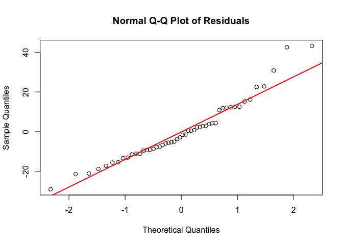

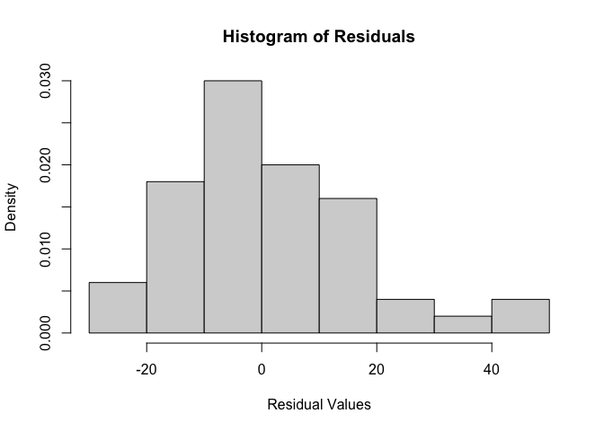

```r
my_plots <- plot_func(fit_my_lm)
```

## Tutorial - Multiple Regression

### Iris Dataset

We can also use the `my_lm()` function to perform multiple linear regression. Compared to simple linear regressions, performed in the example above, multiple linear regressions are used to predict the value of the response variable when two or more covariates are present.

```r
library(macklinear)

head(iris)
```

```
#>   Sepal.Length Sepal.Width Petal.Length Petal.Width Species
#> 1          5.1         3.5          1.4         0.2  setosa
#> 2          4.9         3.0          1.4         0.2  setosa
#> 3          4.7         3.2          1.3         0.2  setosa
#> 4          4.6         3.1          1.5         0.2  setosa
#> 5          5.0         3.6          1.4         0.2  setosa
#> 6          5.4         3.9          1.7         0.4  setosa
```

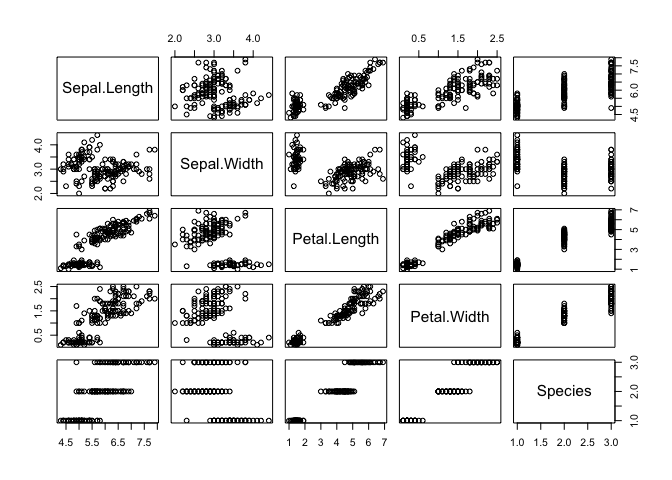

```r
plot(iris)
```

There are four continuous variables in the iris data set that can be used for multiple regression: **sepal length, sepal width, petal length**, and **petal width**.

Using our `my_lm()` function, we want to see if our covariates sepal length and sepal width can explain the relationship in our response variable, petal length.

We will use a **90% confidence interval** and, the **asymptotic** method for the confidence interval, and no intercept.

```r
iris.response <- iris$Petal.Length
iris.covariates <- cbind(iris$Sepal.Length, iris$Sepal.Width)
iris_results <- my_lm(iris.response, iris.covariates, alpha = 0.1, method = "asymptotic", intercept = -1)
iris_results
```

```
#> $y.avg
#>       [,1]
#> [1,] 3.758
#>
#> $sigma2
#>           [,1]
#> [1,] 0.4718147
#>
#> $mspe
#>           [,1]
#> [1,] 0.4655239
#>
#> $ssm
#>          [,1]
#> [1,] 2512.881
```

[output cut: 170 more lines]

From the output, we no longer have the estimate for the intercept, or “b0”. However, now that we have added an additional x value, there now exists a “b1” and a “b2”.

To get our descriptive plots, we can use `plot_func()` with the parameter again the object we called our `my_lm()` function.

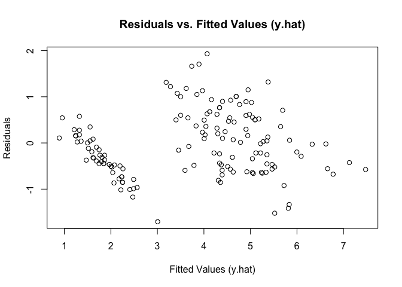

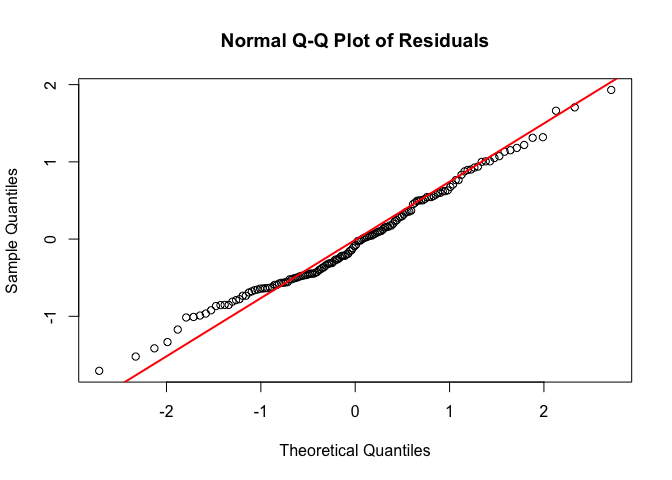

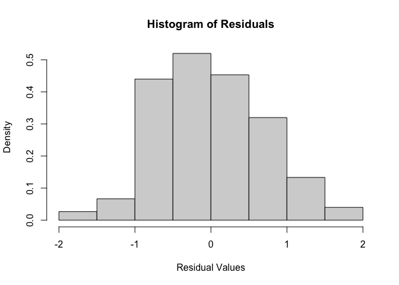

```r
iris_plots <- plot_func(iris_results)
```

## Error Messages and Constraints

There are a few checks built into the function to make sure the regressions are performed accurately. For example, as mentioned before, the function will not run if the `alpha` value is less than 0 or greater than 1. An example of the error output in this situation is below:

```r
iris_results <- my_lm(iris$Petal.Length, iris$Petal.Width, alpha = 2, method = "asymptotic", intercept = 1)
```

```
#> Error in my_lm(iris$Petal.Length, iris$Petal.Width, alpha = 2, method = "asymptotic", : True value of alpha must lie between 0 and 1
```

Another potential error message a user can encounter is when entering the method for generating the confidence interval. If the user enters a method that is unknown, the function will not run:

```r
iris_results <- my_lm(iris$Petal.Length, iris$Petal.Width, alpha = 0.05, method = "unbiased", intercept = 1)
```

```
#> Error in my_lm(iris$Petal.Length, iris$Petal.Width, alpha = 0.05, method = "unbiased", : Unrecognized confidence interval method. Try "asymptotic" or "bootstrap".
```

Additionally, there is one warning that will appear pertaining to `alpha` again, but it will not halt the function. As mentioned earlier, a warning will be produced if the `alpha` value is an uncommon value:

```r
iris_results <- my_lm(iris$Petal.Length, iris$Petal.Width, alpha = 0.4, method = "a", intercept = 1)
```

```
#> Warning in my_lm(iris$Petal.Length, iris$Petal.Width, alpha = 0.4, method =
#> "a", : Alpha is typically between 0.01 and 0.1. Consider using a different alpha
#> value
```

```r
iris_results
```

```
#> $y.avg
#>       [,1]
#> [1,] 3.758
#>
#> $sigma2
#>           [,1]
#> [1,] 0.2286808
#>
#> $mspe
#>           [,1]
#> [1,] 0.2256317
#>
#> $ssm
#>          [,1]
#> [1,] 430.4806
```

[output cut: 170 more lines]